# Sources of variation in the data

2016-07-07

**Last updated:** 2016-08-24

**Code version:** 4fa8d92159a01306030c0d9aee85adf50f860ca9

```r
library("knitr")
opts_chunk$set(cache = FALSE, fig.pos = "center", fig.width = 7, fig.height = 7)
```

## Setup

```r
library("dplyr")
library("tidyr")
library("edgeR")
library("DT")
library("gplots")
library("ggplot2")
library("cowplot")
```

Input data.

```r
counts <- read.delim("../data/counts-filtered.txt", check.names = FALSE,
                     row.names = 1)
info <- read.delim("../data/experiment-info-filtered.txt",
                   stringsAsFactors = FALSE, row.names = 1)
stopifnot(colnames(counts) == rownames(info))
```

Calculate counts per million.

```r
counts_cpm <- cpm(counts, log = TRUE)
```

## PCA

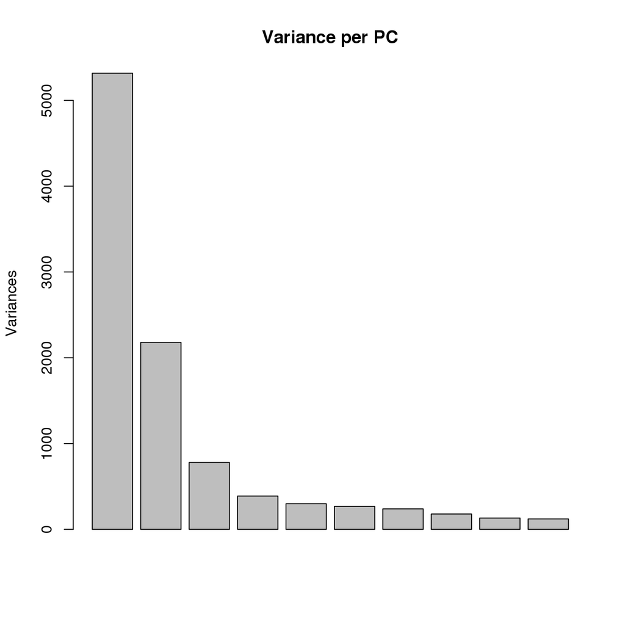

```r
pca <- prcomp(t(counts_cpm), scale. = TRUE)
variances <- pca$sdev^2
explained <- variances / sum(variances)
plot(pca, main = "Variance per PC")
```

```r
p_comps <- 1:6
pc_cov_cor <- matrix(nrow = ncol(info), ncol = length(p_comps),
                     dimnames = list(colnames(info), colnames(pca$x)[p_comps]))
for (pc in p_comps) {
  for (covariate in 1:ncol(info)) {
    lm_result <- lm(pca$x[, pc] ~ info[, covariate])
    r2 <- summary(lm_result)$r.squared
    pc_cov_cor[covariate, pc] <- r2
  }
}
datatable(pc_cov_cor)
```

|  | PC1 | PC2 | PC3 | PC4 | PC5 | PC6 |
| --- | --- | --- | --- | --- | --- | --- |
| individual | 0.123988188840756 | 0.809952504985403 | 0.959252559151705 | 0.539719116234117 | 0.894999315412015 | 0.383870198680599 |
| status | 0.00220113339200245 | 0.00868386027963136 | 0.144364465581603 | 0.0880266487078839 | 0.0393169602841127 | 0.00203208123635658 |
| treatment | 0.951655770307096 | 0.0217206403806811 | 0.000914486968731577 | 0.000648869830374535 | 0.0040319947652856 | 0.00502397971959538 |
| infection | 0.0678189667050394 | 0.405929043266074 | 0.862675397209035 | 0.336473823814533 | 0.701692988370721 | 0.29253591173746 |
| arrival | 0.0129911713967877 | 0.32282489699849 | 0.0364186530980866 | 0.0973244365210885 | 0.412922264519385 | 0.102157869067205 |
| extraction | 0.0234041204603271 | 0.322955932206597 | 0.261832310574474 | 0.101446277755962 | 0.4343935496375 | 0.18632512941689 |
| master_mix | 0.00650302082726462 | 0.0462853996703765 | 0.11397831078209 | 0.080398456769885 | 0.0339335437236402 | 0.163155639081749 |
| rin | 0.00828739144796932 | 0.0762543381520177 | 0.0345442293546218 | 0.00939399237026305 | 0.014574109095298 | 0.0695595949629684 |

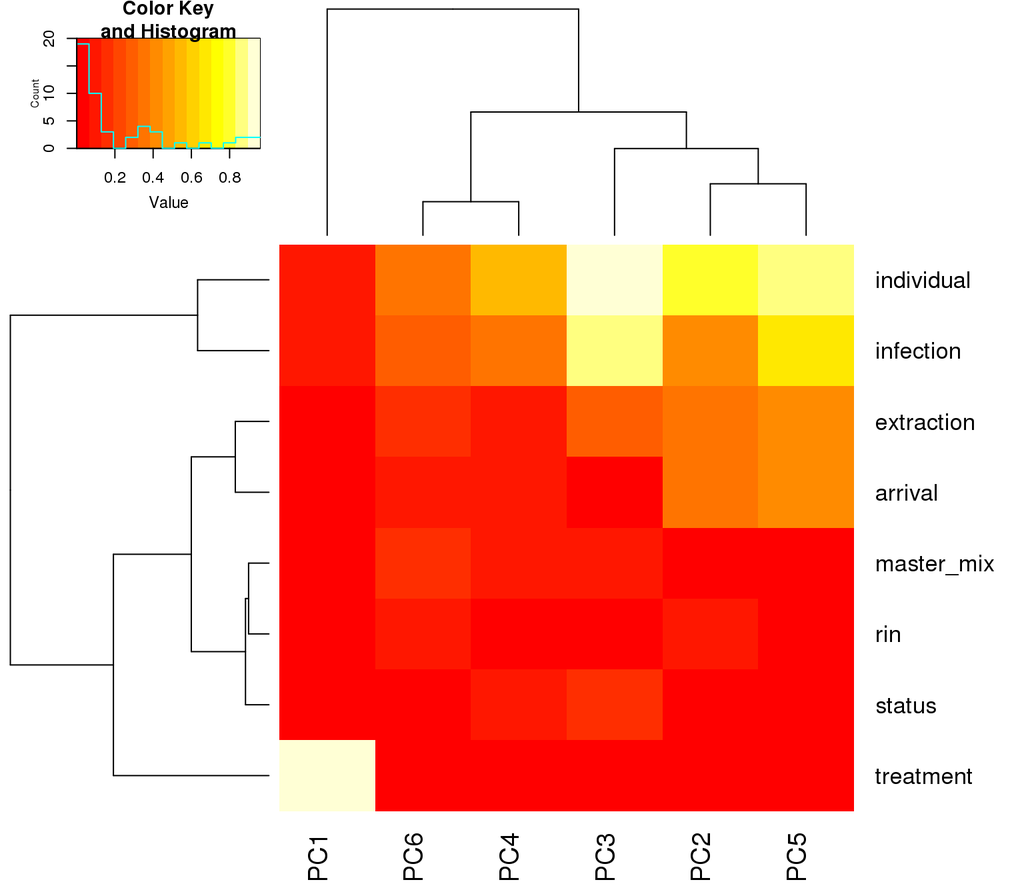

```r
heatmap.2(pc_cov_cor, trace = "none", margins = c(4, 8))
```

```r
pc_cov_cor_2 <- as.data.frame(pc_cov_cor)
pc_cov_cor_2$variable <- rownames(pc_cov_cor)
pc_cov_cor_2 <- gather(pc_cov_cor_2, key = "pc", value = "cor", -variable)
head(pc_cov_cor_2)
```

```
##     variable  pc         cor
## 1 individual PC1 0.123988189
## 2     status PC1 0.002201133
## 3  treatment PC1 0.951655770
## 4  infection PC1 0.067818967
## 5    arrival PC1 0.012991171
## 6 extraction PC1 0.023404120
```

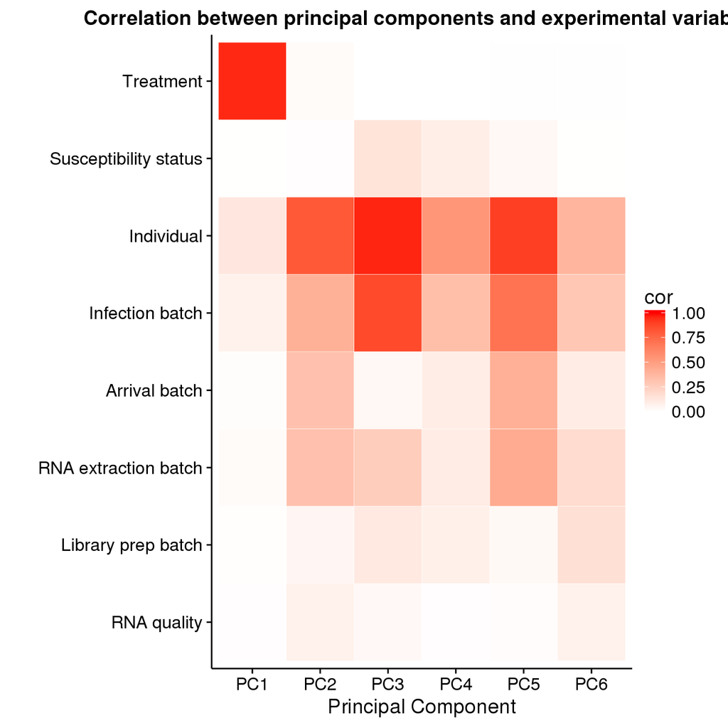

```r
d_heatmap <- pc_cov_cor_2
d_heatmap$variable <- factor(d_heatmap$variable,
                             levels = c("rin", "master_mix",
                                        "extraction", "arrival", "infection",
                                        "individual", "status", "treatment"),
                             labels = c("RNA quality", "Library prep batch",
                                        "RNA extraction batch", "Arrival batch",
                                        "Infection batch", "Individual",
                                        "Susceptibility status", "Treatment"))
pca_heat <- ggplot(d_heatmap, aes(x = pc, y = variable)) +
  geom_tile(aes(fill = cor), colour = "white") +
  scale_fill_gradient(low = "white", high = "red", limits = c(0, 1)) +
  labs(x = "Principal Component", y = "",
       title = "Correlation between principal components and experimental variables")
pca_heat
```

```r
pca_data <- cbind(info, pca$x[, p_comps])
pca_data$status <- factor(pca_data$status, levels = c("contact", "tb"),
                          labels = c("resistant", "susceptible"))
pca_data$treatment <- factor(pca_data$treatment, levels = c("none", "infected"))
```

PC1 versus PC2.

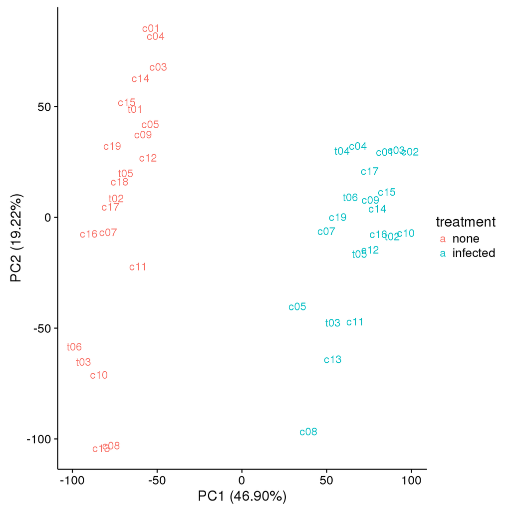

```r
pc1v2 <- ggplot(pca_data, aes(x = PC1, y = PC2, color = treatment)) +
  geom_text(aes(label = individual)) +
  labs(x = sprintf("PC%d (%.2f%%)", 1, round(explained[1] * 100, 2)),
       y = sprintf("PC%d (%.2f%%)", 2, round(explained[2] * 100, 2)))
pc1v2
```

PC3 versus PC4.

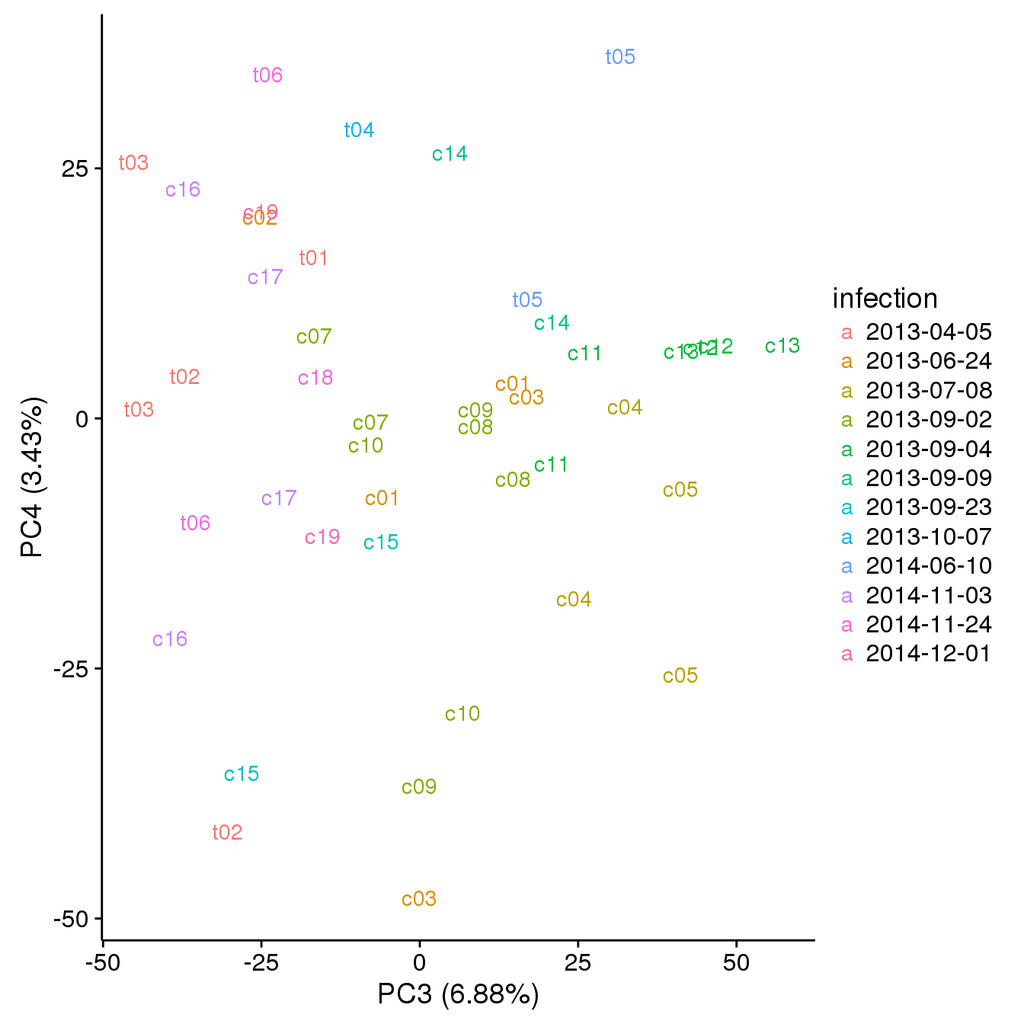

```r
pc3v4 <- ggplot(pca_data, aes(x = PC3, y = PC4, color = infection)) +
  geom_text(aes(label = individual)) +
  labs(x = sprintf("PC%d (%.2f%%)", 3, round(explained[3] * 100, 2)),
       y = sprintf("PC%d (%.2f%%)", 4, round(explained[4] * 100, 2)))
pc3v4
```

PC5 versus PC6.

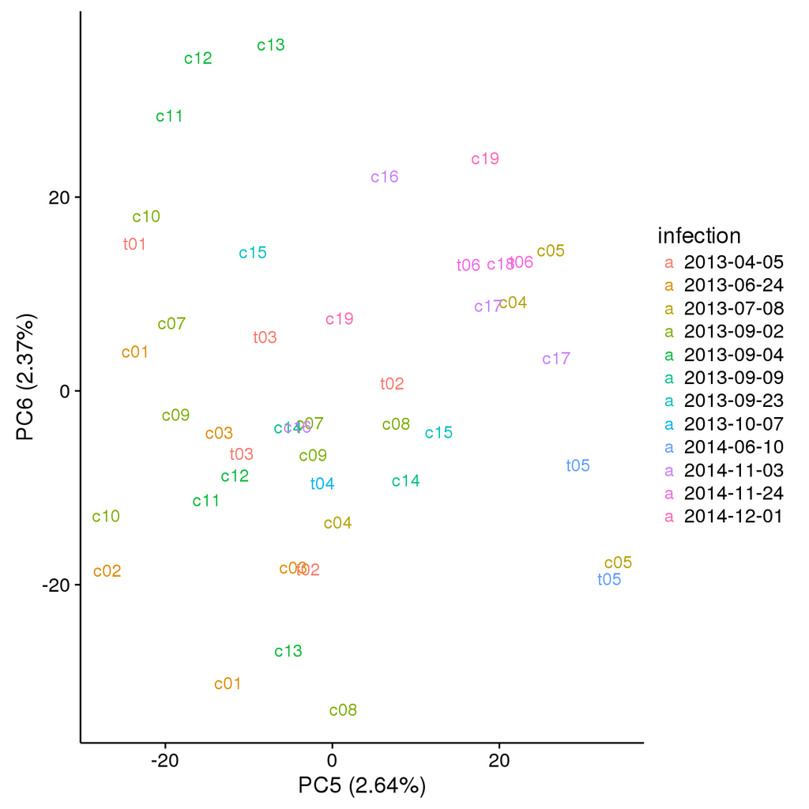

```r
pc5v6 <- ggplot(pca_data, aes(x = PC5, y = PC6, color = infection)) +
  geom_text(aes(label = individual)) +
  labs(x = sprintf("PC%d (%.2f%%)", 5, round(explained[5] * 100, 2)),
       y = sprintf("PC%d (%.2f%%)", 6, round(explained[6] * 100, 2)))
pc5v6
```

## Effect of treatment

PC1 is correlated with treatment.

```r
pc_cov_cor_2 %>% filter(variable == "treatment", cor > 0.5)
```

```
##    variable  pc       cor
## 1 treatment PC1 0.9516558
```

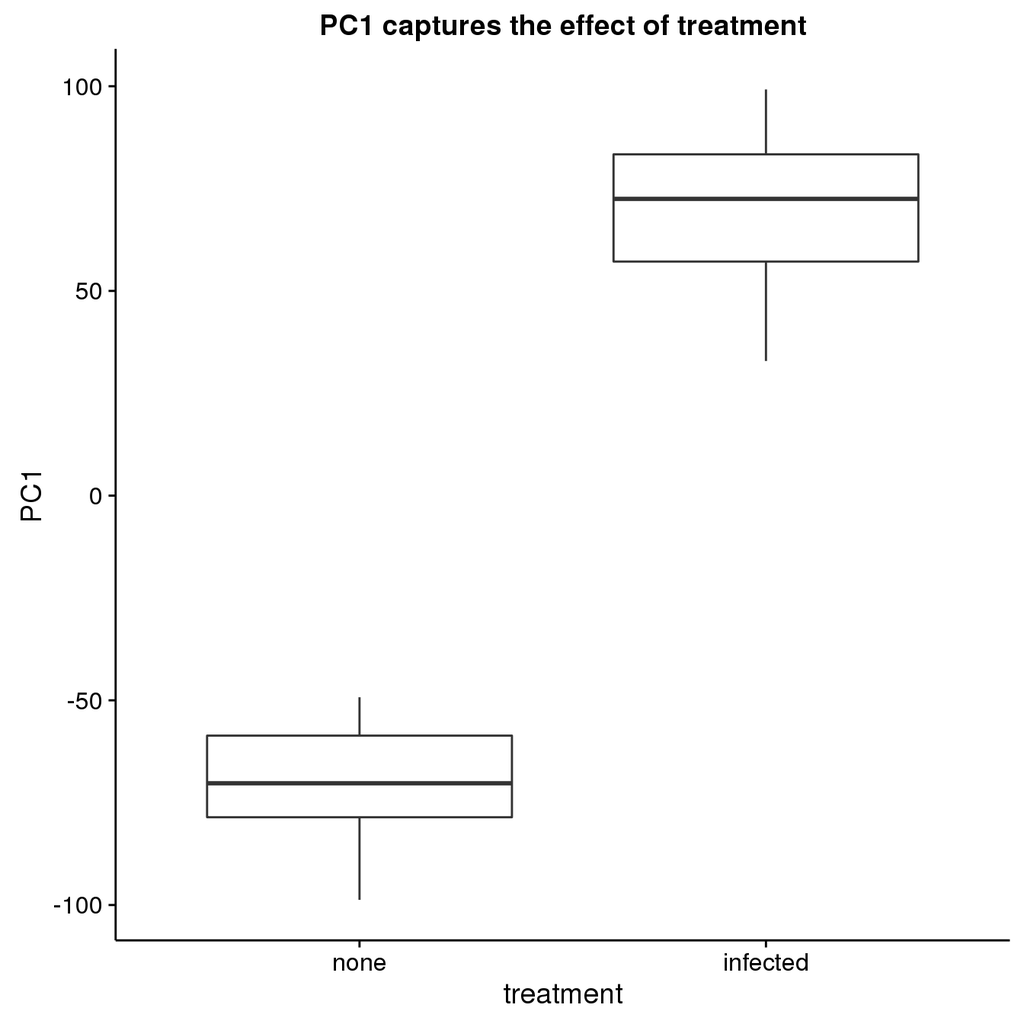

```r
pc1_treatment <- ggplot(pca_data, aes(x = treatment, y = PC1)) +
  geom_boxplot() +
  labs(title = "PC1 captures the effect of treatment")
pc1_treatment
```

## Any technical batch effects?

There are multiple factors with a strong correlation with at least one of the first 6 PCs.

```r
pc_cov_cor_2 %>% filter(cor > 0.5)
```

```
##     variable  pc       cor
## 1  treatment PC1 0.9516558
## 2 individual PC2 0.8099525
## 3 individual PC3 0.9592526
## 4  infection PC3 0.8626754
## 5 individual PC4 0.5397191
## 6 individual PC5 0.8949993
## 7  infection PC5 0.7016930
```

Most of the major correlations are with biological variables: treatment or individual. It is expected that the largest source of variation in gene expression is due to the transcriptional changes induced by the immune response to MTB. Also, we expect there to be differences between individuals, and this will be explicitly modeled for in the differential expression analysis. Thus the main concern is the variable infection. The infection experiments were done as the whole blood samples were obtained, so they are the most confounded with susceptibility status.

```r
pc_cov_cor_2 %>% filter(variable == "infection", cor > 0.5)
```

```
##    variable  pc       cor
## 1 infection PC3 0.8626754
## 2 infection PC5 0.7016930
```

```r
table(info$infection[info$treatment == "none"],
      info$status[info$treatment == "none"])
```

```
##
##              contact tb
##   2013-04-05       0  3
##   2013-06-24       2  0
##   2013-07-08       2  0
##   2013-09-02       4  0
##   2013-09-04       3  0
##   2013-09-09       1  0
##   2013-09-23       1  0
##   2014-06-10       0  1
##   2014-11-03       2  0
##   2014-11-24       1  1
##   2014-12-01       1  0
```

The infection dates with susceptible samples are 2013-04-05, 2014-06-10, and 2014-11-24. We clearly see there is variation in PC3 by the date of the infection experiment.

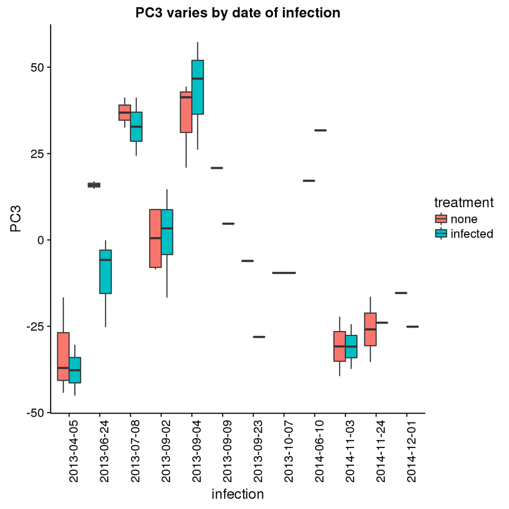

```r
pc3_infection <- ggplot(pca_data, aes(x = infection, y = PC3, fill = treatment)) +
  geom_boxplot() +
  theme(axis.text.x = element_text(angle = 90)) +
  labs(title = "PC3 varies by date of infection")
pc3_infection
```

Reassuringly, however, this variation does not correlate strongly with susceptibilty status.

```r
pc_cov_cor_2 %>% filter(variable == "status", pc == "PC3")
```

```
##   variable  pc       cor
## 1   status PC3 0.1443645
```

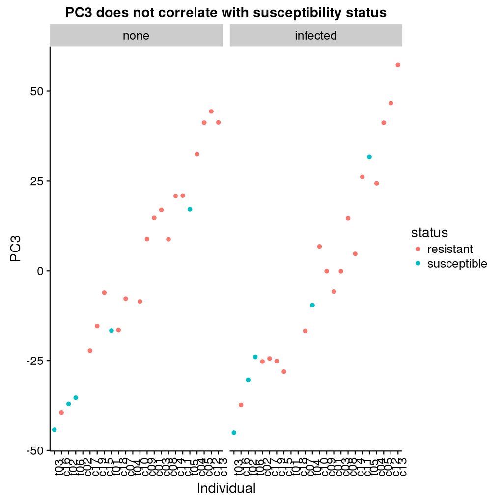

```r
pc3_status <- ggplot(pca_data, aes(x = reorder(individual, PC3), y = PC3, color = status)) +
  geom_point() +
  facet_wrap(~treatment) +
  labs(title = "PC3 does not correlate with susceptibility status",
       x = "Individual") +
  theme(axis.text.x = element_text(angle = 90))
pc3_status
```

The situation is the same with PC5. It varies with infection date.

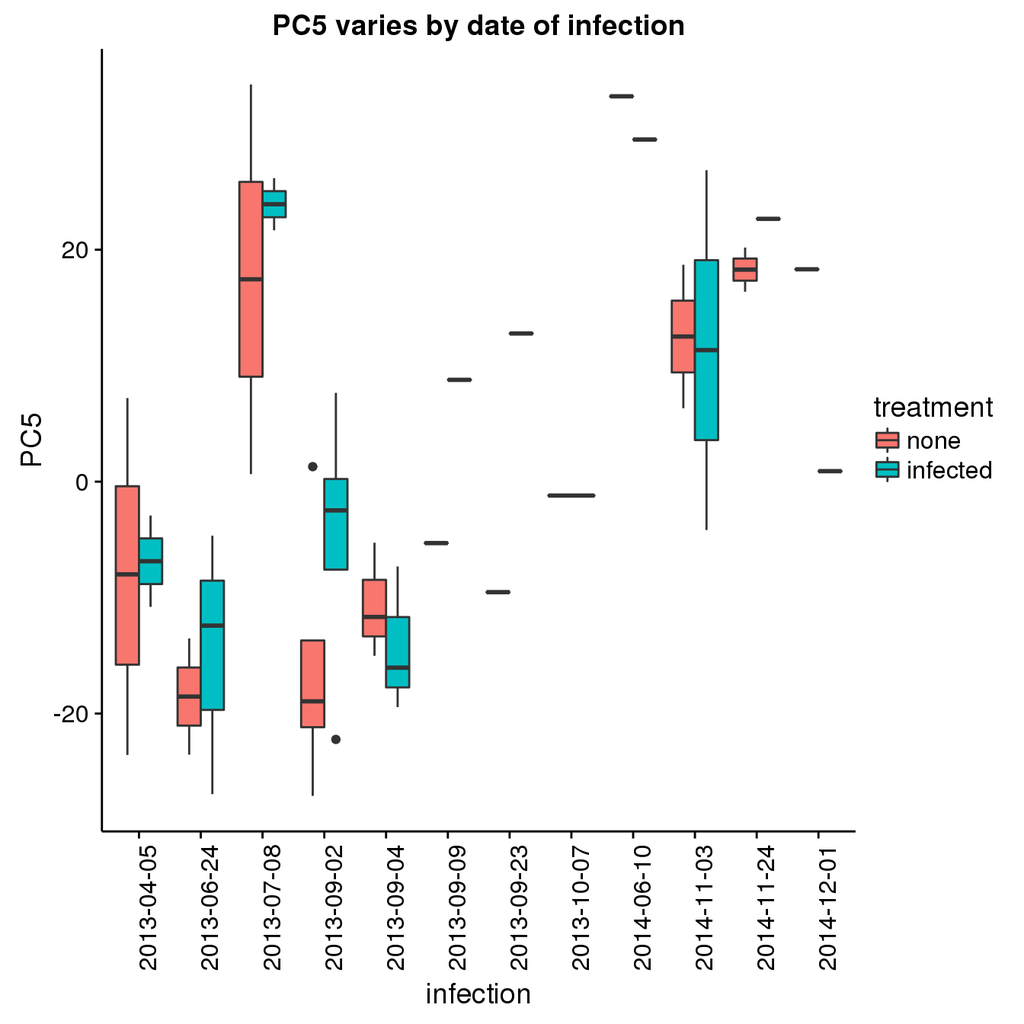

```r
pc5_infection <- pc3_infection %+% aes(y = PC5) +
  labs(title = "PC5 varies by date of infection")
pc5_infection
```

But does not correlate strongly with susceptibilty status.

```r
pc_cov_cor_2 %>% filter(variable == "status", pc == "PC5")
```

```
##   variable  pc        cor
## 1   status PC5 0.03931696
```

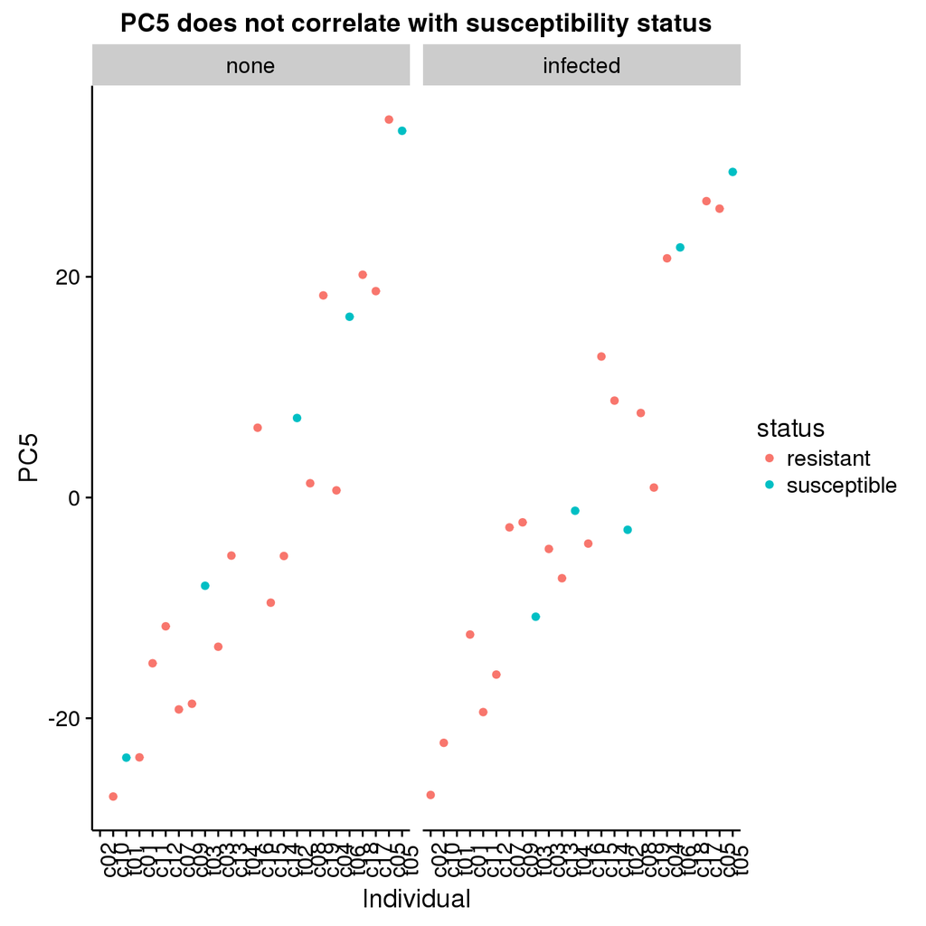

```r
pc5_status <- pc3_status %+% aes(x = reorder(individual, PC5), y = PC5) +
  labs(title = "PC5 does not correlate with susceptibility status",
       x = "Individual")
pc5_status
```

## Multipanel figures

PCA

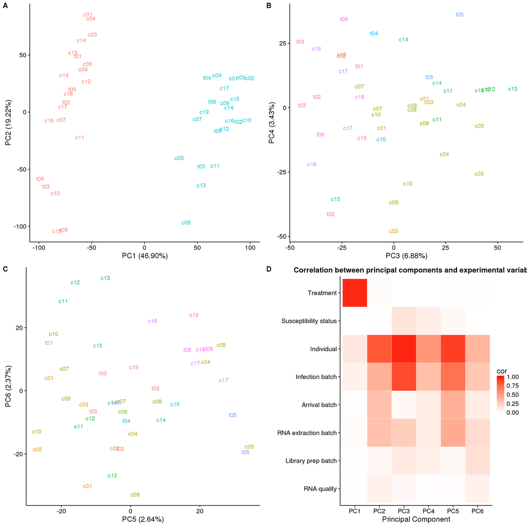

```r
plot_grid(pc1v2 + theme(legend.position = "none"),
          pc3v4 + theme(legend.position = "none"),
          pc5v6 + theme(legend.position = "none"),
          pca_heat,
          labels = LETTERS[1:4])
```

Batch effects

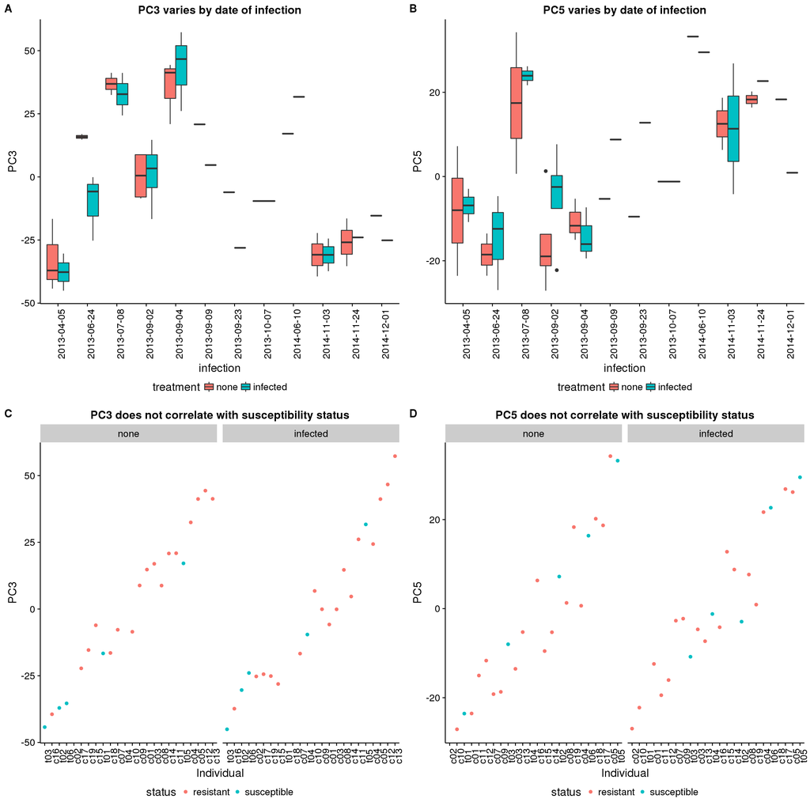

```r
plot_grid(pc3_infection + theme(legend.position = "bottom"),
          pc5_infection  + theme(legend.position = "bottom"),
          pc3_status + theme(legend.position = "bottom"),
          pc5_status + theme(legend.position = "bottom"),
          labels = LETTERS[1:4])
```